# Geospatial Analysis with R

Class 6

Lyndon Estes & Zhiwen Zhu

9/18/2017

# Introduction

- Any lingering questions from last class?
- Today: indexing & control structures, focusing on *apply
- Projects

# Your questions?

- Anything lingering from last class?
- Comfort with indexing?
- *apply?

# Subsetting/Selecting/Indexing 1

### Selecting by index **number**

First make the following:

```r
# a vector with names for each element
a <- 1:10
names(a) <- letters[1:length(a)]

# a matrix
mat <- cbind(a = 1:10, b = 1:10, c = 1:10)
colnames(mat) <- c("a", "b", "c")

# a data.frame
d <- c(rep("pigs", 3), rep("ponies", 4), rep("puppies", 3))
dat <- cbind.data.frame(mat, d)

# a list
l <- list(a, mat, dat)
names(l) <- c("a", "mat", "dat")  # give the list names
```

- Now do the following exercises, in which you select:
  - from `a`:
    - the 10th value;
    - the 1st and 3rd values
    - all but the 5th value
  - from `mat`:
    - row 1, column 1;
    - column 3; row 2
  - from `dat`:
    - rows 2:4 in columns 3:4;
    - rows 2:4 in columns 2 and 4
  - from `l`:
    - the 1st element;
    - the 3rd element;
    - rows 2:4 in col 2 & 4 in the 3rd element

# Answers

### Selecting by index **number**

```r
# Vectors
a[10]  # 10th values of A
a[c(1, 3)]  # 1st and 3rd values in A
a[-5]

# matrices
mat[1, 1]  # row 1, column 1
mat[2, 3]  # row 2, column 3

# data.frames
dat[2:4, 3:4]  # rows 2:4 in columns 3:4
dat[2:4, c(2, 4)]  # rows 2:4 in columns 2 and 4

# lists
l[[1]]  # first element (a)
l[[3]]  # third element (dat)
l[[3]][2:4, c(2, 4)]  # rows 2:4 in col 2 & 4 in 3rd element
```

# Subsetting/Selecting/Indexing 2

### Selecting by index **name**

- Do the following exercises, selecting, using names:
  - from `a`:
    - the element named “f”
  - from `mat`:
    - row 1, column “a”
    - column “b”
  - from `dat`:
    - row 1, column “d”
    - column “c”
  - from `l`:
    - element “a”
    - element “mat”
    - rows 2:4 from columns “b”
    - “d” in element “dat”

# Answers

### Selecting by index name

```r
a["f"]

mat[1, "a"]
mat[, "b"]

dat[1, "d"]
dat[, "c"]

l$a
l$mat
l$dat[2:4, c("b", "d")]
```

# Subsetting/Selecting/Indexing 3

### Selecting by matching values

### Simple matching

```r
dat[dat$d == "pigs", ]  # all rows/columns of dat where d == "pigs"

# another way (if you don't know name of column 4)
dat[dat[, 4] == "pigs", ]  # all rows of dat where d == "pigs"
```

Notice the position where the match is specified (row)

### Partial matching

```r
dat[grep("es", dat$d), ]  # all rows, columns of dat$d containing "es"
dat[grep("up", dat$d), ]  # all rows, columns of dat$d containing "up"
```

### Exercises

- Selecting the following
  - from `dat`:
    - all values from “a” where d contains “puppies”. Write it using both numerical and named index values for column “a”, and for the match to column “d”
    - all values from columns “a”, “b”, “c” where “d” contains “on”

# Answers

### Selecting by simple and partial matching

```r
dat[dat$d == "puppies", 1]  # all values from a where d == "puppies"
dat[dat$d == "puppies", "a"]  # all values from a where d == "puppies"
dat[dat[, 4] == "puppies", 1]  # all values from a where d == "puppies"
dat[dat[, 4] == "puppies", "a"]  # all values from a where d == "puppies"
dat[grep("on", dat$d), 1:3]  # all values from a-c where d contains "on"
```

# Control structures

Very important, particularly the apply family of functions.

- apply, lapply, sapply
- First, `for` loops, which occur in all languages

```r
for(i in 1:10) {
  print(dat[i, "a"] * 10)
}  # Where are the results kept?

a <- rep(NA, 10)
for(i in 1:10) {
  a[i] <- dat[i, "a"] * 10
}  # Where are the results kept?
a
```

- The output of `for` has to be “caught” in an object you define
- One reason we use the `*apply` family is because it is designed to put results into an object
  - the *apply family functions generally take the following form:

  ```
  *apply(data, [an index, maybe], function, function_applied_to_data))
  ```

  - `data` can be a vector or any higher data structure
  - `[index] only certain of the *apply family use an index
  - `function` can be a specific one, or just a placeholder
  - `function_applied_to_data` can be implicit or explicit

# apply

`apply` applies a function to the rows or columns of a data.frame or matrix

```r
aa <- apply(dat[, 1:3], 1, sum)  # sum across columns (aka row sums)
aa
bb <- apply(dat[, 1:3], 2, sum)  # sum across rows (aka column sums)
bb
```

- Here, `[index]` is used, `function` is specific and, `function_applied_to_data` is implicit
- The example below produces the same result, using a placeholder `function`, and an explicitly stated `function_applied_to_data` part of the code

```r
aa <- apply(dat[, 1:3], 1, function(x) sum(x))  # short version
aa
aa <- apply(dat[, 1:3], 1, function(x) {  # full syntax
  sum(x)
})  # sum across columns
aa
```

# lapply

`lapply` also operates on a list, or applies a function to an index of your choosing, but returns a list

`lapply` is arguably the most important of the *apply family to know

```r
ee <- lapply(l, function(x) sum(x[1:2]))
ee
ff <- lapply(1:10, function(x) sum(dat[x, 1:3]))
ff
ff <- lapply(1:10, function(x) {
  print(paste("iteration", x))
  d <- dat[x, 1:3]
  o <- sum(d)
})
ff
```

# sapply

`sapply` is basically a wrapper for lapply, which produces the simplest possible output structure, which can be a `vector`, `matrix`, or `data.frame`. If none of those work, it also returns a `list`.

It takes the same arguments as `lapply`.

```r
cc <- sapply(l, function(x) sum(x[1:2]))
cc
dd <- sapply(1:10, function(x) sum(dat[x, 1:3]))
dd
```

```r
ee <- sapply(1:3, function(x) {
  a <- sum(dat[, x])
  b <- mean(dat[, x])
  c("sum" = a, "mean" = b)
})
ee
```

```
##      [,1] [,2] [,3]
## sum  55.0 55.0 55.0
## mean  5.5  5.5  5.5
```

- In the example above, we use sapply to iterate over the first three columns of dat, and calculate the `sum` and `mean` of each column.
- The output matrix has the statistics by row and the results from each iteration in columns.
- I often find it more intuitive to have the **transpose** of this.

```r
t(ee)
```

```
##      sum mean
## [1,]  55  5.5
## [2,]  55  5.5
## [3,]  55  5.5
```

# `for` versus `apply`

In general, if you want to keep the output of your iterative operation, best look to `*apply`. If not, `for` loops can be useful.

e.g.

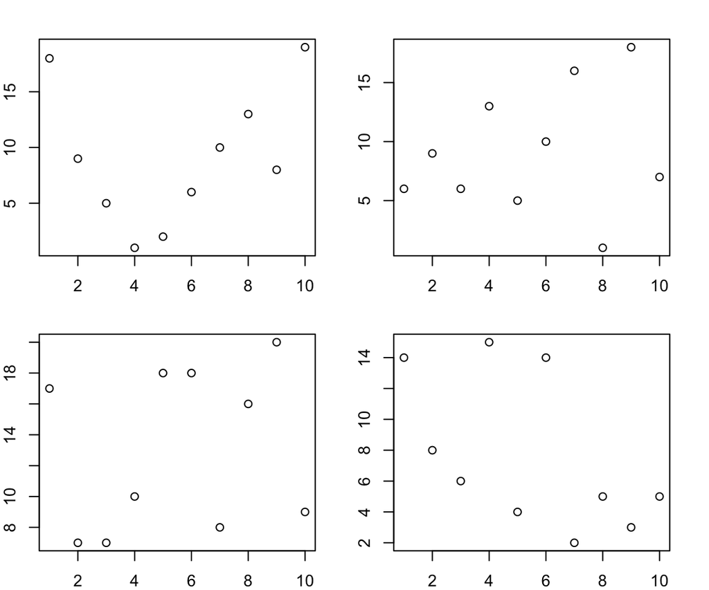

```r
par(mfrow = c(2, 2), mar = c(2, 2, 2, 2))
for(i in 1:4) {
  plot(1:10, sample(0:20, size = 10, replace = TRUE), xlab = "x", ylab = "y")
}
```